```python
from IPython.display import Image
```

# Fase 1: Resolución Conceptual del Problema

# Etapa 1: Etapa 1: Investigación y Análisis Detallado

El problema está dado por la dispersión de los datos. Se mencionan cuatro nodos principales:

1. SFTP
2. Plataformas Propias
3. RudderStack
4. Base de datos plataformas web

Primero, lo más importante es la comunicación y coordinación con el cliente y las distintas partes involucradas. De esto surgen preguntas como: ¿Con qué frecuencia se actualiza la data? ¿A qué hora y qué día? Es de suma importancia lo discutido anteriormente, ya que determina cómo estructuramos las tareas de automatización (cron job u orquestador).

También debemos considerar el estado de los datos y su estructura. Es probable que cada proveedor tenga más o menos atributos, dependiendo del giro y del servicio en el que se especialice. Por lo tanto, es probable que se deba crear un script (Python) para cada proyecto donde aseguremos la consistencia de los esquemas.

Luego podemos aplicar un tratamiento uniforme a todos los datos y, más tarde, exportarlos a una base centralizada (por ejemplo, BigQuery). En este caso, suponemos que haremos el tratamiento en Python.

A continuación, analizaremos más en detalle cada uno de los nodos, junto a los desafíos para cada uno

## 1.1.- SFTP

Para este tipo de herramienta tenemos algunas librerias para poder conectarnos y extraer los datos. Ahora bien, es recomendable seguir algun tipo de estructura en cuanto los a las carpetas donde estara cada informacion. De momento se sugiere que cada cliente tenga su propio folder particionado en servicios y fechas donde el cliente podra dejar a disposicion su data. Un ejemplo podria ser:

```
Fallabella
    |_____SistemaPOS
        |_____202404
            |_____DatosClientes_20240401.csv
            |_____DatosClientes_20240402.xlsx
```

Luego podemos acceder a esta data con modulo en python. Por ejemplo:

```
# Podemos leer la data estructurada desde el SFTP usando librerias.
from io import BytesIO
import paramiko #Existen mas librerias, por lo que hay libertad de elegir la mas conveniente

def read_file_from_sftp(host, port, username, password, remote_path):
    with paramiko.Transport((host, port)) as transport:
        transport.connect(username=username, password=password)
        sftp = paramiko.SFTPClient.from_transport(transport)
        with sftp.open(remote_path, 'r') as file:
            data = file.read()
    return pd.read_csv(BytesIO(data))  #pd.read_excel(BytesIO(data))
```

Finalmente algunos posibles desafios que puede presentar esta solución:

1. Estamos tomando como supuesto que la data esta estructurada. Si fuese no estructurada entonces deberemos tomar otro approach (Modelo de `NLP` puede ser una solución)
2. Debe haber alguna plataforma que haga como intermediaria entre el usuario que sube el archivo y su meta data. Por ejemplo un usuario podria subir un archivo con la fecha equivocada o en un servicio equivocado, despues de todo los errores humanos son bastante comunes.
3. Otra solucion seria conectarse directamente al datalake del cliente mediantes conexiones compartidas en SQL.

## 1.2.- Plataformas Propias

En este punto tomamos el supuesto que la data es guardada en un servidor MSSQL, ya que es lo usual para este tipo de aplicaciones. Con lo anterior planteado, podemos acceder a las bases sin problemas usando librerias como `SQLAlchemy`.

## 1.3.- Flujo Rudderstack

### Connections

Tenemos la chance de usar python para generar nuestra connection.

[figure not shown]

### Destination

Aqui existen alternativas segun lo que use la empresa. Puede ser base de datos SQL (BigQuery, MSSQL, Postgress,etc), o algun web service como Amazon S3.

[figure not shown]

En este ejemplo usaremos BigQuery. Dicho esto, uno de los requerimientos es alamcenar los datos dentro de la plataforma. En el siguiente cuadro tenemos los costos/GB para data que se usa con alta frecuencia:

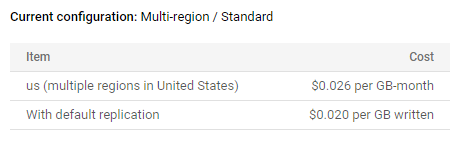

Terminamos de configurar:

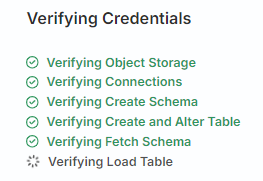

### Transformations (Opcional)

El siguiente paso podria ser aplicar transformacion directa de los datos en rudderstack. Aunque una mejor opcion podria ser hacer esto paso en python para que todos los flujos pasen por el mismo proceso.

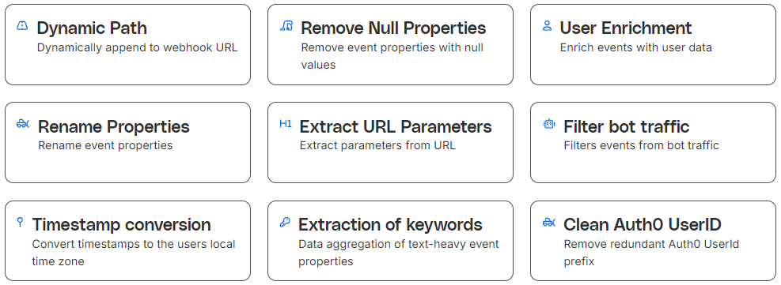

### Testeo

Hacemos algunas pruebas. Si bien no hay certeza de como estara la info estrucutrada en RudderStack, podemos observar que logramos mandar data y que esta sea almacenada en formato de tabla:

```
# pip install rudder-sdk-python -q

import rudderstack.analytics as rudder_analytics

rudder_analytics.write_key = "2eucWRqH2oPrMIaroEo1n5J6vKd"
rudder_analytics.dataPlaneUrl = "https://fashionspazvps.dataplane.rudderstack.com"

#Ingresamos datos
rudder_analytics.track('123456', 'Article Read', {
    'title': 'The Independence',
    'subtitle': 'Story of the Weak',
    'author': 'John Doe'
})
```

[figure not shown]

Pudimos experimentar que **podemos** hacer un pipeline desde RudderStack hacia BigQuery. Lo que no queda claro es:

1. El formato en el que se almacenan los datos en esta herramienta. Es formato tabla? Habria que experimentar con sample de dataset real para entenderlo mejor.
2. Si lo anterior se cumple. Podemos consultar esta data mediante el SDK y trabajar la data desde python (limpieza de datos, integracion con otras fuentes, etc.)

### 1.4.- Plataformas web

En este tipo de plataformas es interesante saber si tiene algun tipo de `API` el cual podamos usar para extraer la informacion que necesitamos. Si no es el caso entonces se puede desarrollar algun tipo de `web-scrapping` que rescate las funtes requeridas.

# Etapa 2: Diseño de Diagrama de Bases de Datos

## 2.1.- Diagrama ER

A continuacion presentaremos un diagrama ER para el caso, donde analizaremos distintas etapas:

1. **Analisis de requerimientos:** Sondear necesidades y entender tareas criticas de cada aplicacación
2. **Diseño Conceptual:**

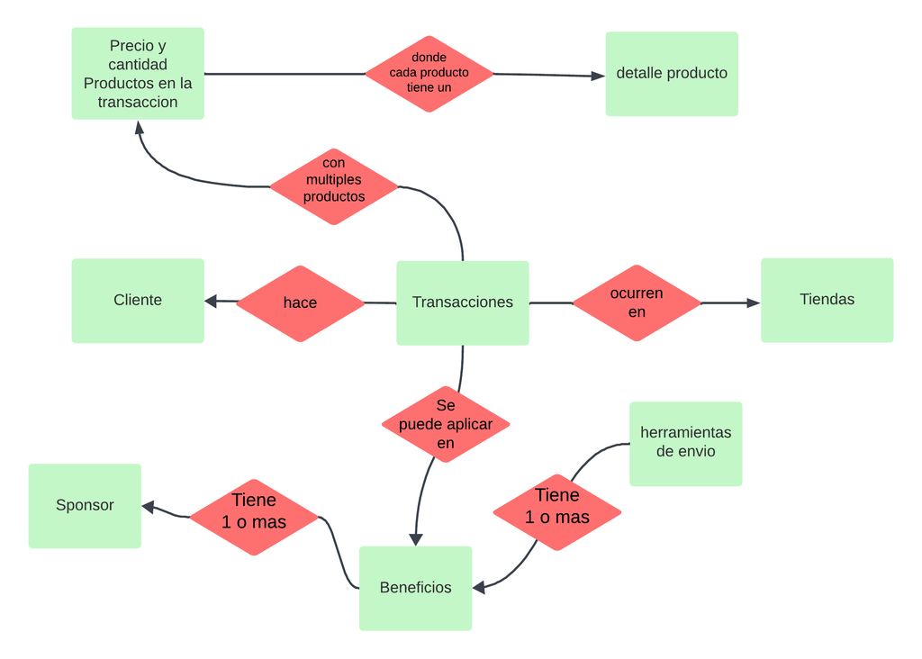

```python
display(Image(filename='ER_conceptual.png', width=1000,height=900))
```

3. **Diseño Logico:**

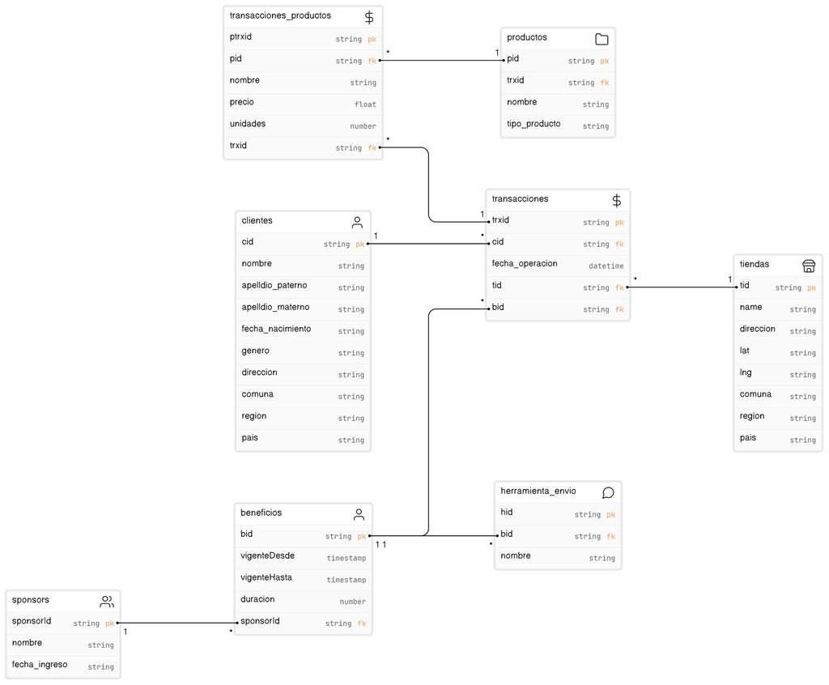

```python
display(Image(filename='ER_blanco.png',width=1100,height=1000))
```

## 2.2.- Sincronizacion

Tomando en cuenta la etapa 1, entonces sabemos que estos flujos estan sujetos a cron job o un orquestador.

## 2.3.- Herramientas

Finalmente se suigiere que las herramientas para lograr este flujo sea:

- `Airflow`: Orquestador
- `Python`: Pipelines y preprocesamiento
- `BigQuery o MSSQL`: Centralizacion de datos
- `GitHub`: Versionamiento

# Fase 2: Explotación de Información

# Etapa 1: Segmentacion de clientes

Primero es importante hacernos la pregunta, `¿Cual es el proposito de la segmentacion?` y `¿Que vamos a hacer con esta segementacion?`. Estas preguntas estan estrechamentes relacionada al modelo necesario. Por ejemplo si la segmentacion tiene como proposito indentificar los clientes que se fugan de los que no lo hacen, quizas no basta con entregar un prediccion. Es posible que debamos alinearnos con algun indicador del negocio.

Segundo es considerar si efectivamente es necesario un modelo de ML, o simplemente basta con un usar una metrica mas tradicional (por lo tanto mas interpretable), por ejemplo `RFM`.

Si tenemos algun kpi o metrica conocida (Modelo Supervisado), podriamos considerar discretizar y usar modelos de segmentacion para predecir cierta metricas. Por otro lado, si queremos crear grupos desde cero (Modelo No Supervisado), entonces podemos usar modelos como `KNN`.

**Datos Necesarios:** Las variables pueden variar de caso a caso, pero se sugieren como punto de partida `Informacion Demografica`, `Historial de Transacciones`, `Historial de Raclamos`, `proxies de la industria` entre otros.

**Criterios Especificos:** Algunos criterios especificos para la segmentacion tales como; `Rango Etario`, `Genero`, `Tiempo de Recompra`, `Estacionalidad`, `Numero de Reclamos`, etc.

**Relevancia:** Podemos usar tecnicas de feature selection, tales como; Feature Importance, LASSO, Ridge, Chi-Square test.

# Etapa 2: Desarrollo de metricas (feature engineer)

Segun lo anterior se propone desarrollar algunas metricas:

- `Nivel de uso y engagement`, `Preferncia por Tipo de Servicio`, `Fidelizacion del cliente`, `Satisfaccion del Cliente`
- Numero de campañas y productos generados por la segmentacion

*Como sabemos si es buena? Usando `mutual information` (entropy loss)*

Adicionalmente se presenta un modelo para mejorar la satisfaccion del cliente:

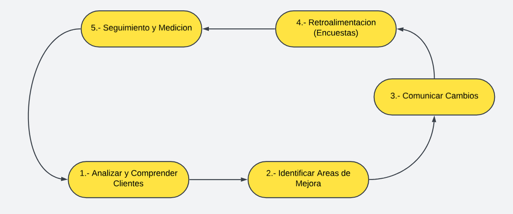

# Fase 3: Carta Gantt

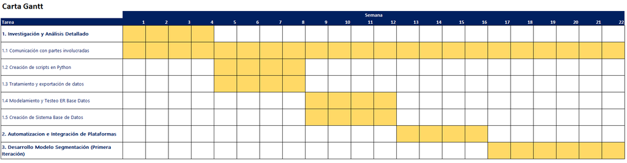